# INFSCI 2595 Final Project

Part 4C, Interpretation - Prediction

Zhenyu Li

2022-04-25

```r
library(tidyverse)
theme_set(theme_linedraw())
library(tidymodels)
tidymodels_prefer()
library(vip)
source("./scripts/utils.R")
```

```r
df <- readr::read_csv("./data/final_project_train.csv", col_names = TRUE)
df_regr <- df %>% select(-c(rowid,outcome)) %>% mutate(response = log(response))
df_clas <- df %>% select(-c(rowid,response))
```

Tasks

- You must visualize the trends associated with the hardest to predict customer with respect to the most important sentiment derived feature.
  - Free to select whether you wish to visualize the regression model trends (transformed response) or the classification model trends (event probability).
  - Predictions should be made using the best performing model.
- You must visualize your predictive trends using the following style:
  - The primary input should be used as the x-aesthetic in a graphic.
  - The secondary input should be used as a facet variable – it is recommended to use 4 to 6 unique values if your secondary input is a continuous variable.
  - You must decide what values to use for the remaining inputs.
- What conclusions can you draw from the predictive trends?

## Predict Hard to Predict Customer

**Read in the respective best model for each task.**

```r
mod_regr <- readr::read_rds("./models/mod_2D_enet_best_wflow")
mod_regr_fit <- mod_regr %>% fit(df_regr)
readr::write_rds(mod_regr_fit, "./models/mod_regr_best.rds")

mod_clas <- readr::read_rds("./models/mod_3D_enet_best_wflow")
mod_clas_fit <- mod_clas %>% fit(df_clas)
readr::write_rds(mod_clas_fit, "./models/mod_clas_best.rds")
```

## Regression

For my best regression model, the most important continuous feature is the `xw_01`, followed by `xa_08`. The most unpredictable customer for the regression task is customer `K`, which is only present in region `ZZ`.

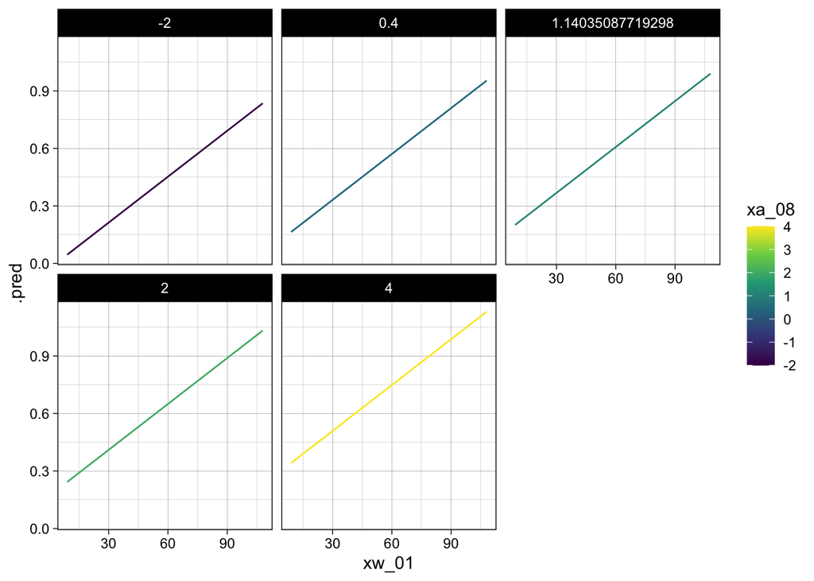

```r
my_inputs <- setdiff(names(df_regr),"response")
viz_grid <- make_test_input_grid(my_inputs, df_regr, c("xw_01","xa_08")) %>%
  mutate(customer = "K", region = "ZZ")

predict(mod_regr_fit, new_data = viz_grid) %>% bind_cols(viz_grid) %>%
  ggplot() +
  geom_line(aes(x=xw_01,y=.pred,color=xa_08)) +
  facet_wrap(~xa_08) +
  scale_color_viridis_c()
```

- For the regression task, my best model is a Elastic Net model. The prediction appears to be linearly related to the primary input. This is expected as the underlying model is just a linear model without nonlinear basis.
- From the prediction, the response increase as either input increases.

## Classification

For my best classification model, the top 2 ranked important features are `xn_01`, `xn_03`. The most unpredictable customer for the classification task is customer `Other`, which is most abundant in region `YY`.

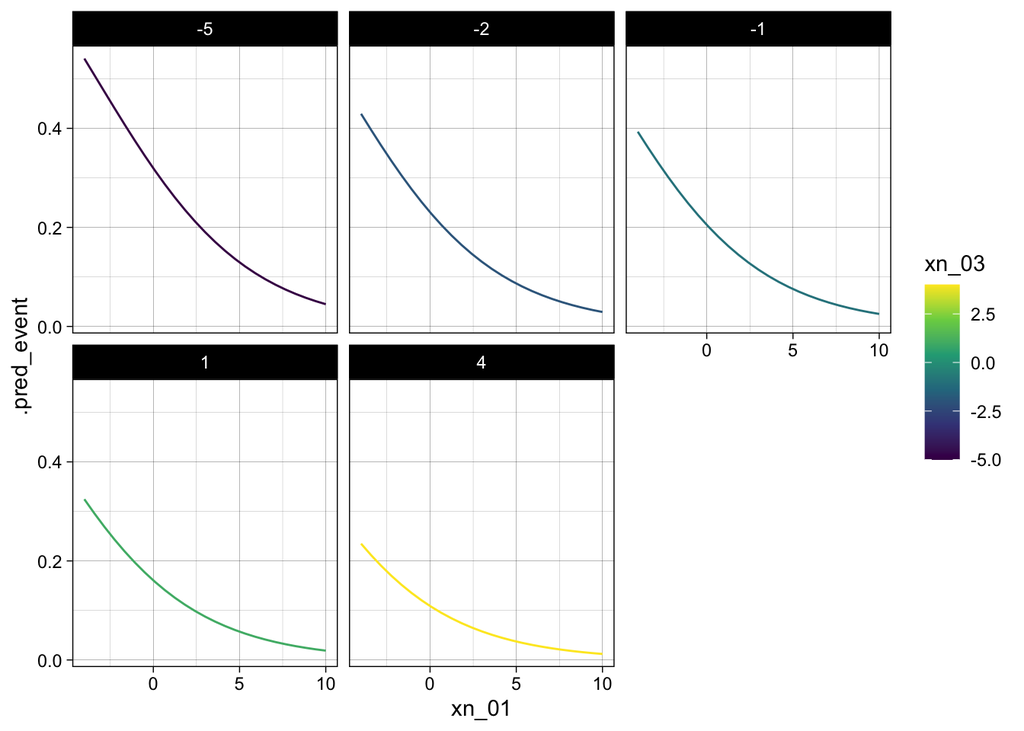

```r
my_inputs <- setdiff(names(df_clas),"outcome")
viz_grid <- make_test_input_grid(my_inputs, df_clas, c("xn_01","xn_03")) %>%
  mutate(customer = "Other", region = "YY")

predict(mod_clas_fit, new_data = viz_grid, type = "prob") %>%
  bind_cols(viz_grid) %>%
  ggplot() +
  geom_line(aes(x=xn_01,y=.pred_event,color=xn_03)) +
  facet_wrap(~xn_03) +
  scale_color_viridis_c()
```

## Predict the Holdout Set

```r
holdout <- readr::read_csv('./data/final_project_holdout_inputs.csv', col_names = TRUE)
my_pred <-
  predict(mod_regr_fit, new_data = holdout) %>%
  cbind(predict(mod_clas_fit, new_data = holdout, type = "prob")) %>%
  rename("y"=.pred, "probability"=.pred_event) %>%
  rowid_to_column(var="id") %>%
  select(-.pred_non_event) %>%
  mutate(outcome=ifelse(probability>=0.5,"event","non-event"))

readr::write_csv(my_pred, "my_holdout_pred.csv")
```

**Compute metrics**

https://anastasia-sosnovskikh.shinyapps.io/infsci2595-spring2022/